# 20191102 Preliminary Analysis

Hanqian Zhang

11/2/2019

## Setup

### Load Packages

```r
library(ggplot2)
library(dplyr)
library(statsr)
library(gmodels)
```

### Load Data

```r
library(haven)
cfps2018person_201909 <- read_dta("D:/CFPS Research-20191101T212903Z-001/CFPS Research/Data/[CFPS+Public+Data]+CFPS+2018+in+STATA+(Chinese)/[CFPS Public Data] CFPS 2018 in STATA (Chinese)/cfps2018person_201909.dta")
library(haven)
cfps2018famecon_201909 <- read_dta("D:/CFPS Research-20191101T212903Z-001/CFPS Research/Data/[CFPS+Public+Data]+CFPS+2018+in+STATA+(Chinese)/[CFPS Public Data] CFPS 2018 in STATA (Chinese)/cfps2018famecon_201909.dta")
```

### Dispatched Worker

Creating a dataframe of dispatched workers & contract workers respectively.

```r
dispatched2018 <- cfps2018person_201909 %>%
  filter(!(is.na(qg502)), qg502 == 1)

cfps2018person_201909 <- cfps2018person_201909 %>%
  mutate(dispatch = ifelse(qg502 == 1, "Dispatch", ifelse(qg5 == 1 & qg502 == 5, "Contract", "Other")))


contract2018 <- cfps2018person_201909 %>%
  filter(!(is.na(qg502)), qg5 == 1, qg502 == 5)

cfps2018person_201909 <- cfps2018person_201909 %>%
  mutate(contract = ifelse(qg5 == 1 & qg502 == 5, TRUE, FALSE))
```

### Preliminary analysis of dispatched workers:

```r
summary(dispatched2018$qg5)
```

```
##    Min. 1st Qu.  Median    Mean 3rd Qu.    Max.
##       1       1       1       1       1       1
```

```r
summary(dispatched2018$qg501)
```

```
##    Min. 1st Qu.  Median    Mean 3rd Qu.    Max.
##       1       1       1       1       1       1
```

The results indicate that all 906 dispatched workers recorded have a labor contract with specified length.

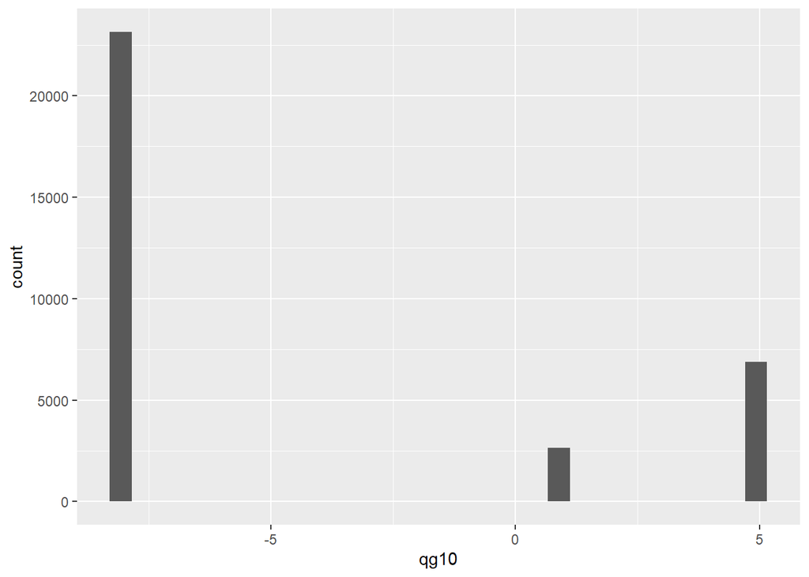

```r
ggplot(data = cfps2018person_201909, aes(x = qg10)) +
  geom_bar(stat = "bin")
```

### 公积金

劳务派遣公积金平均值（380.7）中位数（300）均低于合同工平均值（501）中位数（350）。

派遣工中没有公积金记录的比例（0.608）略高于合同工（0.535）。

派遣工中明确回答没有住房公积金的比例（0.536）略高于合同工（0.466）。

```r
gjjContract <- contract2018 %>%
  filter(!(is.na(qg1001)), qg1001 != -8, qg1001 != -2, qg1001 != -1)

gjjDispatch <- dispatched2018 %>%
  filter(!(is.na(qg1001)), qg1001 != -8, qg1001 != -2, qg1001 != -1)

summary(gjjContract$qg1001)
```

```
##    Min. 1st Qu.  Median    Mean 3rd Qu.    Max.
##       0     200     350     501     620    4600
```

```r
summary(gjjDispatch$qg1001)
```

```
##    Min. 1st Qu.  Median    Mean 3rd Qu.    Max.
##     0.0   165.0   300.0   380.7   500.0  2650.0
```

```r
length(which(contract2018$qg1001 == -8))/count(contract2018)
```

```
##           n
## 1 0.5354257
```

```r
length(which(dispatched2018$qg1001 == -8))/count(dispatched2018)
```

```
##           n
## 1 0.6081678
```

```r
length(which(contract2018$qg10 == 5))/count(contract2018)
```

```
##           n
## 1 0.4658173
```

```r
length(which(dispatched2018$qg10 == 5))/count(dispatched2018)
```

```
##           n
## 1 0.5364238
```

#### 保险

合同工和派遣工无保险记录的比例相近（合同工0.298，派遣工0.302）。

```r
length(which(contract2018$qg901 == -8))/count(contract2018)
```

```
##           n
## 1 0.2977004
```

```r
length(which(dispatched2018$qg901 == -8))/count(dispatched2018)
```

```
##           n
## 1 0.3024283
```

在cfps有保险记录的人当中，合同工平均保险缴纳金额（564.17）和中位数（390)均高于派遣工平均值（439.09）和中位数（320）。

```r
contract2018 %>%
  filter(qg901 != -8, qg901 != -2, qg901 != -1) %>%
  summarise(count = n(), CIMean = mean(qg901), CIMed = median(qg901), CISd = sd(qg901), CIMin = min(qg901), CIMax = max(qg901))
```

```
## # A tibble: 1 x 6
##   count CIMean     CIMed  CISd CIMin CIMax
##   <int>  <dbl> <dbl+lbl> <dbl> <dbl> <dbl>
## 1  1901   564.       390  745.     0 21000
```

```r
dispatched2018 %>%
  filter(qg901 != -8, qg901 != -2, qg901 != -1) %>%
  summarise(count = n(), DIMean = mean(qg901), DIMed = median(qg901), DISd = sd(qg901), DIMin = min(qg901), DIMax = max(qg901))
```

```
## # A tibble: 1 x 6
##   count DIMean     DIMed  DISd DIMin DIMax
##   <int>  <dbl> <dbl+lbl> <dbl> <dbl> <dbl>
## 1   545   439.       320  383.     0  3000
```

### 福利金额

派遣工福利平均金额（1488.89）和中位数（960）均小于合同工（1666.67/1000）

```r
contract2018 %>%
  filter(qg702 != -8, qg702 != -2, qg702 != -1) %>%
  summarise(count = n(), CWMean = mean(qg702), CWMed = median(qg702), CWSd = sd(qg702), CWMin = min(qg702), CWMax = max(qg702))
```

```
## # A tibble: 1 x 6
##   count CWMean CWMed  CWSd CWMin CWMax
##   <int>  <dbl> <dbl> <dbl> <dbl> <dbl>
## 1   636  1667.  1000 3218.     5 50000
```

```r
dispatched2018 %>%
  filter(qg702 != -8, qg702 != -2, qg702 != -1) %>%
  summarise(count = n(), DWMean = mean(qg702), DWMed = median(qg702), DWSd = sd(qg702), DWMin = min(qg702), DWMax = max(qg702))
```

```
## # A tibble: 1 x 6
##   count DWMean     DWMed  DWSd DWMin DWMax
##   <int>  <dbl> <dbl+lbl> <dbl> <dbl> <dbl>
## 1   177  1489.       960 2392.     8 25000
```

### 晋升渠道

派遣工和合同工在过去一年晋升几率很接近（0.134 vs 0.140）

```r
length(which(contract2018$qg15 == 1 | contract2018$qg15 == 2|contract2018$qg15 == 3))/count(contract2018)
```

```
##           n
## 1 0.1395277
```

```r
length(which(dispatched2018$qg15 == 1 | dispatched2018$qg15 == 2|dispatched2018$qg15 == 3))/count(dispatched2018)
```

```
##           n
## 1 0.1335541
```

```r
length(which(contract2018$qg405 == 4 | contract2018$qg405 == 5))/count(contract2018)
```

```
##          n
## 1 0.387197
```

```r
length(which(dispatched2018$qg405 == 4 | dispatched2018$qg405 == 5))/count(dispatched2018)
```

```
##           n
## 1 0.3399558
```

### 其他特征

1. 工作性质（农业 vs 非农)

劳务派遣集中于非农工作岗位。

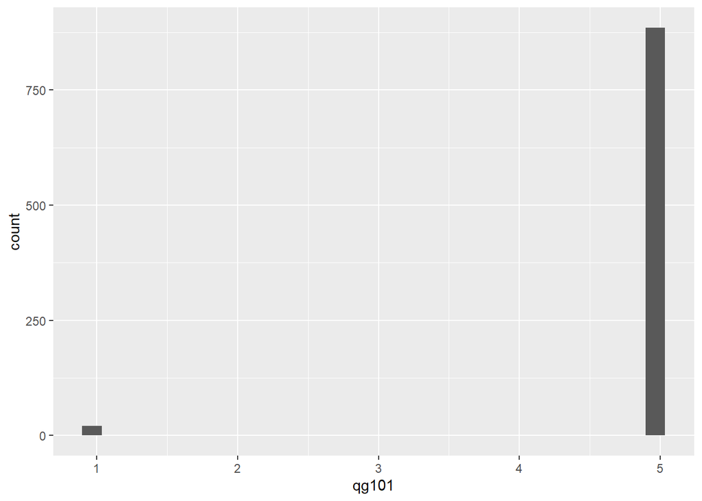

```r
ggplot(dispatched2018, aes(x = qg101))+
  geom_histogram()
```

#### 工会

Surprisingly, 有19.6%的派遣工是工会成员，虽然低于合同工的25.6%

```r
length(which(dispatched2018$qn4003 == 1))/count(dispatched2018)
```

```
##          n
## 1 0.196468
```

```r
length(which(dispatched2018$qn4003 == 1))
```

```
## [1] 178
```

```r
length(which(contract2018$qn4003 == 1))/count(contract2018)
```

```
##           n
## 1 0.2560597
```

```r
length(which(contract2018$qn4003 == 1))
```

```
## [1] 824
```

#### 教育

2018 数据集当中貌似没有教育部分的数据？

#### 心理健康/幸福感

派遣工和合同工对自己生活满意程度接近（3.903 vs 3.893）。

```r
contract2018 %>%
  filter(qn12012 != -8, qn12012 != -2, qn12012 != -1) %>%
  summarise(count = n(), CSMean = mean(qn12012), CSMed = median(qn12012), CSSd = sd(qn12012), CSMin = min(qn12012), CSMax = max(qn12012))
```

```
## # A tibble: 1 x 6
##   count CSMean     CSMed  CSSd CSMin CSMax
##   <int>  <dbl> <dbl+lbl> <dbl> <dbl> <dbl>
## 1  3217   3.89         4 0.855     1     5
```

```r
dispatched2018 %>%
  filter(qn12012 != -8, qn12012 != -2, qn12012 != -1) %>%
  summarise(count = n(), DSMean = mean(qn12012), DSMed = median(qn12012), DSSd = sd(qn12012), DSMin = min(qn12012), DSMax = max(qn12012))
```

```
## # A tibble: 1 x 6
##   count DSMean DSMed  DSSd DSMin DSMax
##   <int>  <dbl> <dbl> <dbl> <dbl> <dbl>
## 1   906   3.90     4 0.934     1     5
```

派遣工和合同工对自己未来信心程度接近（4.17 vs 4.12） 对提高生活水平持积极态度的比率分别为 0.787 & 0.818

```r
contract2018 %>%
  filter(qn12016 != -8, qn12016 != -2, qn12016 != -1) %>%
  summarise(count = n(), CSMean = mean(qn12016), CSMed = median(qn12016), CSSd = sd(qn12016), CSMin = min(qn12016), CSMax = max(qn12016))
```

```
## # A tibble: 1 x 6
##   count CSMean     CSMed  CSSd CSMin CSMax
##   <int>  <dbl> <dbl+lbl> <dbl> <dbl> <dbl>
## 1  3217   4.13         4 0.825     1     5
```

```r
dispatched2018 %>%
  filter(qn12016 != -8, qn12016 != -2, qn12016 != -1) %>%
  summarise(count = n(), DSMean = mean(qn12016), DSMed = median(qn12016), DSSd = sd(qn12016), DSMin = min(qn12016), DSMax = max(qn12016))
```

```
## # A tibble: 1 x 6
##   count DSMean DSMed  DSSd DSMin DSMax
##   <int>  <dbl> <dbl> <dbl> <dbl> <dbl>
## 1   906   4.17     4 0.858     1     5
```

```r
length(which(contract2018$wv108 == 3 | contract2018$wv108 == 4))/count(contract2018)
```

```
##           n
## 1 0.8182101
```

```r
length(which(dispatched2018$wv108 == 3 | dispatched2018$wv108 == 4))/count(dispatched2018)
```

```
##           n
## 1 0.7869757
```

认为自己是失败者的比例都很低： 派遣工0.33% 合同工0.25%

```r
length(which(contract2018$qm103m == 3 | contract2018$qm103m == 4))/count(contract2018)
```

```
##             n
## 1 0.002486016
```

```r
length(which(dispatched2018$qm103m == 3 | dispatched2018$qm103m == 4))/count(dispatched2018)
```

```
##             n
## 1 0.003311258
```

认为自己幸福程度派遣工和合同工很接近（7.572 vs 7.62）

```r
contract2018 %>%
  filter(qm2016 >= 0) %>%
  summarise(count = n(), CSMean = mean(qm2016), CSMed = median(qm2016), CSSd = sd(qm2016), CSMin = min(qm2016), CSMax = max(qm2016))
```

```
## # A tibble: 1 x 6
##   count CSMean     CSMed  CSSd CSMin CSMax
##   <int>  <dbl> <dbl+lbl> <dbl> <dbl> <dbl>
## 1  3217   7.62         8  1.82     0    10
```

```r
dispatched2018 %>%
  filter(qm2016 >= 0) %>%
  summarise(count = n(), DSMean = mean(qm2016), DSMed = median(qm2016), DSSd = sd(qm2016), DSMin = min(qm2016), DSMax = max(qm2016))
```

```
## # A tibble: 1 x 6
##   count DSMean     DSMed  DSSd DSMin DSMax
##   <int>  <dbl> <dbl+lbl> <dbl> <dbl> <dbl>
## 1   905   7.57         8  2.01     0    10
```

认为热门大多是乐于助人的比例派遣工略低于合同工（69.76% vs 73.12%）

```r
length(which(contract2018$qm6 == 1))/count(contract2018)
```

```
##           n
## 1 0.7311995
```

```r
length(which(dispatched2018$qm6 == 1))/count(dispatched2018)
```

```
##           n
## 1 0.6975717
```

认为努力有回报和认为聪明才干有回报的比例相近： 努力（派遣工83.11% vs 83.25%合同工） 聪明才干（派遣工83.44% vs 82.97%合同工）

```r
length(which(contract2018$wv104 == 3 | contract2018$wv104 == 4))/count(contract2018)
```

```
##           n
## 1 0.8325047
```

```r
length(which(dispatched2018$wv104 == 3 | dispatched2018$wv104 == 4))/count(dispatched2018)
```

```
##           n
## 1 0.8311258
```

```r
length(which(contract2018$wv105 == 3 | contract2018$wv105 == 4))/count(contract2018)
```

```
##           n
## 1 0.8297079
```

```r
length(which(dispatched2018$wv105 == 3 | dispatched2018$wv105 == 4))/count(dispatched2018)
```

```
##           n
## 1 0.8344371
```

针对工作的幸福感派遣工人和合同工均非常接近： 工作收入满意度（派遣工 3.35 vs 3.38 合同工） 工作环境满意度（派遣工 3.71 vs 3.69 合同工） 工作时间满意度（派遣工 3.61 vs 3.61 合同工） 工作晋升满意度（派遣工 3.27 vs 3.34 合同工） 工作（总体）满意度（派遣工3.66 vs 3.69合同工）

```r
contract2018 %>%
  filter(qg401 >= 0) %>%
  summarise(count = n(), CSMean = mean(qg401), CSMed = median(qg401), CSSd = sd(qg401))
```

```
## # A tibble: 1 x 4
##   count CSMean        CSMed  CSSd
##   <int>  <dbl>    <dbl+lbl> <dbl>
## 1  3217   3.38 4 [比较满意] 0.963
```

```r
dispatched2018 %>%
  filter(qg401 >= 0) %>%
  summarise(count = n(), DSMean = mean(qg401), DSMed = median(qg401), DSSd = sd(qg401))
```

```
## # A tibble: 1 x 4
##   count DSMean DSMed  DSSd
##   <int>  <dbl> <dbl> <dbl>
## 1   906   3.35     4 0.984
```

```r
contract2018 %>%
  filter(qg403 >= 0) %>%
  summarise(count = n(), CSMean = mean(qg403), CSMed = median(qg403), CSSd = sd(qg403))
```

```
## # A tibble: 1 x 4
##   count CSMean CSMed  CSSd
##   <int>  <dbl> <dbl> <dbl>
## 1  3218   3.69     4 0.944
```

```r
dispatched2018 %>%
  filter(qg403 >= 0) %>%
  summarise(count = n(), DSMean = mean(qg403), DSMed = median(qg403), DSSd = sd(qg403))
```

```
## # A tibble: 1 x 4
##   count DSMean DSMed  DSSd
##   <int>  <dbl> <dbl> <dbl>
## 1   906   3.71     4 0.947
```

```r
contract2018 %>%
  filter(qg404 >= 0) %>%
  summarise(count = n(), CSMean = mean(qg404), CSMed = median(qg404), CSSd = sd(qg404))
```

```
## # A tibble: 1 x 4
##   count CSMean CSMed  CSSd
##   <int>  <dbl> <dbl> <dbl>
## 1  3218   3.61     4  1.00
```

```r
dispatched2018 %>%
  filter(qg404 >= 0) %>%
  summarise(count = n(), DSMean = mean(qg404), DSMed = median(qg404), DSSd = sd(qg404))
```

```
## # A tibble: 1 x 4
##   count DSMean DSMed  DSSd
##   <int>  <dbl> <dbl> <dbl>
## 1   906   3.61     4  1.02
```

```r
length(which(contract2018$qg405 == 79))/count(contract2018)
```

```
##           n
## 1 0.2759478
```

```r
length(which(dispatched2018$qg405 == 79))/count(dispatched2018)
```

```
##           n
## 1 0.3300221
```

```r
contract2018 %>%
  filter(qg405 >= 0 & qg405 != 79) %>%
  summarise(count = n(), CSMean = mean(qg405), CSMed = median(qg405), CSSd = sd(qg405))
```

```
## # A tibble: 1 x 4
##   count CSMean CSMed  CSSd
##   <int>  <dbl> <dbl> <dbl>
## 1  2326   3.34     4  1.01
```

```r
dispatched2018 %>%
  filter(qg405 >= 0 & qg405 != 79) %>%
  summarise(count = n(), DSMean = mean(qg405), DSMed = median(qg405), DSSd = sd(qg405))
```

```
## # A tibble: 1 x 4
##   count DSMean DSMed  DSSd
##   <int>  <dbl> <dbl> <dbl>
## 1   606   3.27     4  1.05
```

```r
contract2018 %>%
  filter(qg406 >= 0) %>%
  summarise(count = n(), CSMean = mean(qg406), CSMed = median(qg406), CSSd = sd(qg406))
```

```
## # A tibble: 1 x 4
##   count CSMean CSMed  CSSd
##   <int>  <dbl> <dbl> <dbl>
## 1  3218   3.69     4 0.808
```

```r
dispatched2018 %>%
  filter(qg406 >= 0) %>%
  summarise(count = n(), DSMean = mean(qg406), DSMed = median(qg406), DSSd = sd(qg406))
```

```
## # A tibble: 1 x 4
##   count DSMean DSMed  DSSd
##   <int>  <dbl> <dbl> <dbl>
## 1   906   3.66     4 0.825
```

#### 健康

主观认为不健康比例差不多（派遣工6.4% vs 6.3% 合同工） 客服健康变化也差不多（健康恶化比例 派遣工24.4% vs 24.9%合同工）

```r
length(which(contract2018$qp201 == 5))/count(contract2018)
```

```
##            n
## 1 0.06339341
```

```r
length(which(dispatched2018$qp201 == 5))/count(dispatched2018)
```

```
##            n
## 1 0.06401766
```

```r
length(which(contract2018$qp202 == 5))/count(contract2018)
```

```
##           n
## 1 0.2489124
```

```r
length(which(dispatched2018$qp202 == 5))/count(dispatched2018)
```

```
##           n
## 1 0.2439294
```

#### 政府合法性

派遣工对政府官员的信任程度略低于合同工（派遣工4.71 vs 4.85合同工）。 对本县市政府评价相近（派遣工2.56 vs 2.55合同工） 认为政府腐败程度相近（派遣工 7.15 vs 7.09 合同工) 认为我国贫富差距问题程度相近（派遣工 7.63 vs 7.63 合同工) 认为我国就业问题程度派遣工略高于合同工（派遣工 7.01 vs 6.89 合同工) 认为我国社会保障问题程度相近（派遣工 6.72 vs 6.68 合同工)

```r
contract2018 %>%
  filter(qn10025 >= 0) %>%
  summarise(count = n(), CSMean = mean(qn10025), CSMed = median(qn10025), CSSd = sd(qn10025))
```

```
## # A tibble: 1 x 4
##   count CSMean     CSMed  CSSd
##   <int>  <dbl> <dbl+lbl> <dbl>
## 1  3201   4.85         5  2.35
```

```r
dispatched2018 %>%
  filter(qn10025 >= 0) %>%
  summarise(count = n(), DSMean = mean(qn10025), DSMed = median(qn10025), DSSd = sd(qn10025))
```

```
## # A tibble: 1 x 4
##   count DSMean DSMed  DSSd
##   <int>  <dbl> <dbl> <dbl>
## 1   904   4.71     5  2.47
```

```r
contract2018 %>%
  filter(qn1101 >= 0) %>%
  summarise(count = n(), CSMean = mean(qn1101), CSMed = median(qn1101), CSSd = sd(qn1101))
```

```
## # A tibble: 1 x 4
##   count CSMean CSMed  CSSd
##   <int>  <dbl> <dbl> <dbl>
## 1  3164   2.55     2 0.897
```

```r
dispatched2018 %>%
  filter(qn1101 >= 0) %>%
  summarise(count = n(), DSMean = mean(qn1101), DSMed = median(qn1101), DSSd = sd(qn1101))
```

```
## # A tibble: 1 x 4
##   count DSMean          DSMed  DSSd
##   <int>  <dbl>      <dbl+lbl> <dbl>
## 1   899   2.56 2 [有一定成绩] 0.909
```

```r
contract2018 %>%
  filter(qn6011 >= 0) %>%
  summarise(count = n(), CSMean = mean(qn6011), CSMed = median(qn6011), CSSd = sd(qn6011))
```

```
## # A tibble: 1 x 4
##   count CSMean CSMed  CSSd
##   <int>  <dbl> <dbl> <dbl>
## 1  3170   7.09     7  2.41
```

```r
dispatched2018 %>%
  filter(qn6011 >= 0) %>%
  summarise(count = n(), DSMean = mean(qn6011), DSMed = median(qn6011), DSSd = sd(qn6011))
```

```
## # A tibble: 1 x 4
##   count DSMean DSMed  DSSd
##   <int>  <dbl> <dbl> <dbl>
## 1   900   7.15     8  2.52
```

```r
contract2018 %>%
  filter(qn6014 >= 0) %>%
  summarise(count = n(), CSMean = mean(qn6014), CSMed = median(qn6014), CSSd = sd(qn6014))
```

```
## # A tibble: 1 x 4
##   count CSMean CSMed  CSSd
##   <int>  <dbl> <dbl> <dbl>
## 1  3208   6.89     7  2.12
```

```r
dispatched2018 %>%
  filter(qn6014 >= 0) %>%
  summarise(count = n(), DSMean = mean(qn6014), DSMed = median(qn6014), DSSd = sd(qn6014))
```

```
## # A tibble: 1 x 4
##   count DSMean     DSMed  DSSd
##   <int>  <dbl> <dbl+lbl> <dbl>
## 1   901   7.01         7  2.16
```

```r
contract2018 %>%
  filter(qn6013 >= 0) %>%
  summarise(count = n(), CSMean = mean(qn6013), CSMed = median(qn6013), CSSd = sd(qn6013))
```

```
## # A tibble: 1 x 4
##   count CSMean     CSMed  CSSd
##   <int>  <dbl> <dbl+lbl> <dbl>
## 1  3215   7.63         8  2.00
```

```r
dispatched2018 %>%
  filter(qn6013 >= 0) %>%
  summarise(count = n(), DSMean = mean(qn6013), DSMed = median(qn6013), DSSd = sd(qn6013))
```

```
## # A tibble: 1 x 4
##   count DSMean DSMed  DSSd
##   <int>  <dbl> <dbl> <dbl>
## 1   904   7.63     8  2.12
```

```r
contract2018 %>%
  filter(qn6018 >= 0) %>%
  summarise(count = n(), CSMean = mean(qn6018), CSMed = median(qn6018), CSSd = sd(qn6018))
```

```
## # A tibble: 1 x 4
##   count CSMean CSMed  CSSd
##   <int>  <dbl> <dbl> <dbl>
## 1  3210   6.68     7  2.36
```

```r
dispatched2018 %>%
  filter(qn6018 >= 0) %>%
  summarise(count = n(), DSMean = mean(qn6018), DSMed = median(qn6018), DSSd = sd(qn6018))
```

```
## # A tibble: 1 x 4
##   count DSMean     DSMed  DSSd
##   <int>  <dbl> <dbl+lbl> <dbl>
## 1   903   6.72         7  2.47
```